# Spotify - Midpoint Deliverable

Andrew Chan, Olivia Hokama, Derek Hong, Paul Pham

May 24, 2019

## Introduction

Our team chose to work with Spotify, and more specifically music in general, as our area of interest. For many of us, music represents a constant and consistent source of enjoyment, and provides a much needed accompaniment to many parts of our lives. We chose this domain not only because we love music, but also because we believe that music can show us interesting trends across generations and allow us to better understand the preferences of the general population.

We’ll be taking an overall look at different song trends, then diving deeper into greater detail about certain attributes of popular music.

### Our Data

This table is being included because of its importance in understanding the overall trends of music over the course of several years. By using yearly aggregates of a few important trends, we can hopefully deduce where music is going in the future, and where it used to be. For example, while danceability seems to have remained somewhat constant, the energy has interestingly went down in recent times. It also shows that perhaps despite the conceptions people have had about music trends, components of the music have actually stayed relatively consistent.

[output not shown]

### Song Trends in the 2000s

Here in this chart we took a look at different attributes of popular songs starting from the beginning of the 2000. We took a look at features such as the **average speechiness, average energy, average danceability,** and **acousticness**. Here we wanted to point out how these certain features from different songs change over time as different popular songs are produced.

**Speechiness** detects the presence of spoken words in a track. If the speechiness of a song is above 0.66, it is probably made of spoken words, a score between 0.33 and 0.66 is a song that may contain both music and words, and a score below 0.33 means the song does not have any speech.

**Energy** represents a perceptual measure of intensity and activity. Typically, energetic tracks feel fast, loud, and noisy”.

**Danceability** describes how suitable a track is for dancing based on a combination of musical elements including tempo, rhythm stability, beat strength, and overall regularity. A value of 0.0 is least danceable and 1.0 is most danceable.

**Acousticness** describes how acoustic a song is. A score of 1.0 means the song is most likely to be an acoustic one.

[Source](https://towardsdatascience.com/is-my-spotify-music-boring-an-analysis-involving-music-data-and-machine-learning-47550ae931de)

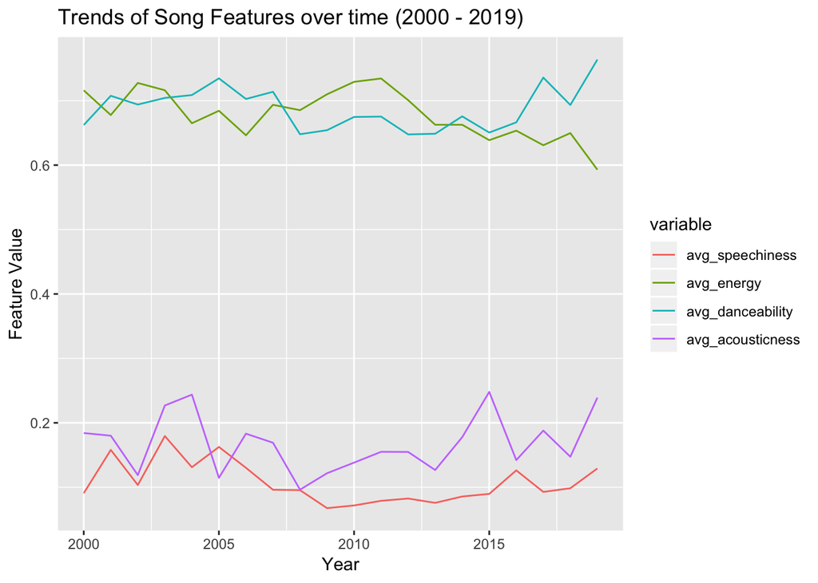

### Dancibility Trends

In this chart, we took a look at the **danceability** trends of popular songs from the 2000 - 2019. This chart takes the average dancibility rating that Spotify gives each song from the data and plots it.

In this chart we see that the average **danceability** rating of popular music from 2019 has only increased slightly compared to the beginning of 2000

[figure not shown]

### Speechiness Trends

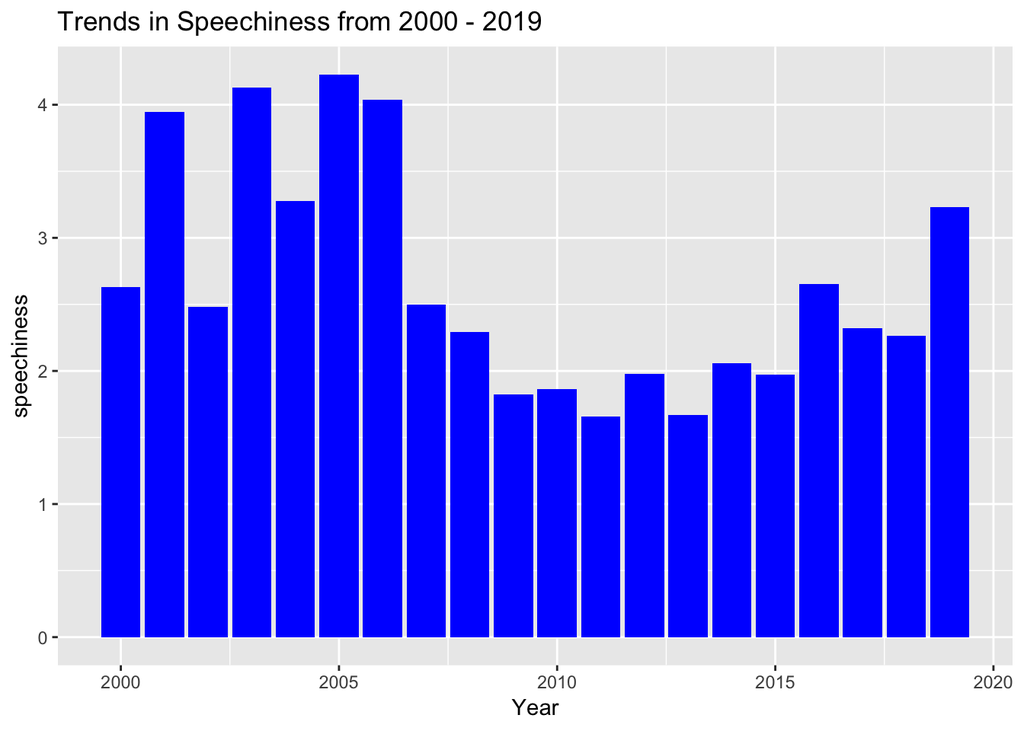